# Modélisation

SANON Korossin

02/03/2026

```r
rm(list=ls())
```

## 1 Modelisation du montant total :

```r
Base_sim <- read.csv2("data_sim.csv", fileEncoding = "Latin1") # problème d'encodage à l'import

Base_sim$sexe <- as.factor(Base_sim$sexe)
Base_sim$qualite <- as.factor(Base_sim$qualite)
Base_sim$codeGarantie <- as.factor(Base_sim$codeGarantie)
```

```r
str(Base_sim)
```

[output not shown]

### 1.1 Analyse de correlation

> Montant total

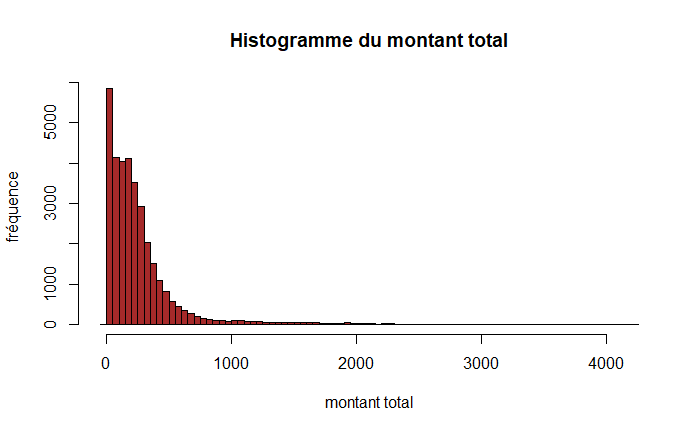

```r
hist(Base_sim$Mtt_total, breaks = 100, freq = TRUE, main = "Histogramme du montant total",
     xlab = "montant total", ylab = "fréquence", col = "brown")
```

```r
summary(Base_sim$Mtt_total)
```

```
    Min.  1st Qu.   Median     Mean  3rd Qu.     Max.
  -1.268   81.112  183.985  265.599  317.412 4205.706
```

```r
nrow(Base_sim[Base_sim$Mtt_total == 0,])/nrow(Base_sim)*100
```

```
[1] 0
```

```r
nrow(Base_sim[Base_sim$Mtt_total <= 30,])/nrow(Base_sim)*100
```

```
[1] 12.55177
```

> Montant total et age

```r
summary(Base_sim$Age)
```

```
   Min. 1st Qu.  Median    Mean 3rd Qu.    Max.
   0.10   55.40   71.10   65.29   81.60  108.80
```

```r
# Corrélation
cor(Base_sim$Mtt_total, Base_sim$Age, method = "spearman")
```

```
[1] 0.01368558
```

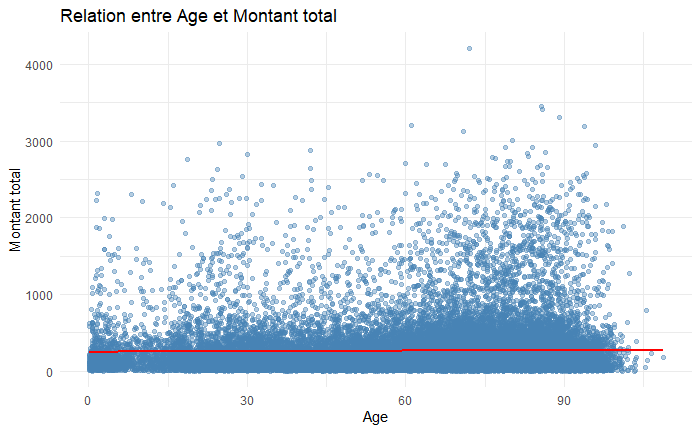

```r
# Graphique
ggplot(Base_sim, aes(x = Age, y = Mtt_total)) +
  geom_point(alpha = 0.4, color = "steelblue") +
  geom_smooth(method = "lm", color = "red", se = TRUE) +
  labs(title = "Relation entre Age et Montant total",
       x = "Age",
       y = "Montant total") +
  theme_minimal()
```

> Montant total et sexe

```r
# Univarié
describe(Base_sim$sexe)
```

```
[33804 obs.]
nominal factor: "M" "F" "F" "F" "F" "M" "M" "F" "M" "M" ...
2 levels: F | M
NAs: 0 (0%)

          n     %
F     18370  54.3
M     15434  45.7
Total 33804 100.0
```

```r
# test de student
t.test(Mtt_total ~ sexe, data = Base_sim)
```

```
    Welch Two Sample t-test

data:  Mtt_total by sexe
t = 34.898, df = 31612, p-value < 2.2e-16
alternative hypothesis: true difference in means between group F and group M is not equal to 0
95 percent confidence interval:
 111.8328 125.1426
sample estimates:
mean in group F mean in group M
       319.6972        201.2094
```

```r
# Bivarié
print(aggregate(Mtt_total ~ sexe, data = Base_sim, FUN = mean))
```

```
  sexe Mtt_total
1    F  319.6972
2    M  201.2094
```

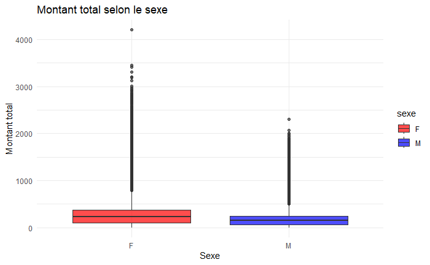

```r
# boxplot
ggplot(Base_sim, aes(x = sexe, y = Mtt_total, fill = sexe)) +
  geom_boxplot(alpha = 0.7) +
  labs(title = "Montant total selon le sexe", x = "Sexe", y = "Montant total") +
  scale_fill_manual(values = c("red","blue")) +
  theme_minimal()
```

> Montant total et garantie

```r
# Univarié
describe(Base_sim$codeGarantie)
```

```
[33804 obs.]
nominal factor: "ATR+" "ATR1" "ATR+" "ATR1" "ATR1" "ATR1" "ATR1" "ATR2" "ATR1" "ATR1" ...
5 levels: ATR+ | ATR1 | ATR2 | ATR3 | ATR4
NAs: 0 (0%)

          n     %
ATR+   2959   8.8
ATR1  13383  39.6
ATR2   9408  27.8
ATR3   6519  19.3
ATR4   1535   4.5
Total 33804 100.0
```

```r
# test non parametrique de Kruskal-Wallis
kruskal.test(Mtt_total ~ codeGarantie, data = Base_sim)
```

```
    Kruskal-Wallis rank sum test

data:  Mtt_total by codeGarantie
Kruskal-Wallis chi-squared = 6817, df = 4, p-value < 2.2e-16
```

```r
# Bivarié
print(aggregate(Mtt_total ~ codeGarantie, data = Base_sim, FUN = mean))
```

```
  codeGarantie Mtt_total
1         ATR+  931.7605
2         ATR1  136.3054
3         ATR2  219.3816
4         ATR3  274.5901
5         ATR4  353.7812
```

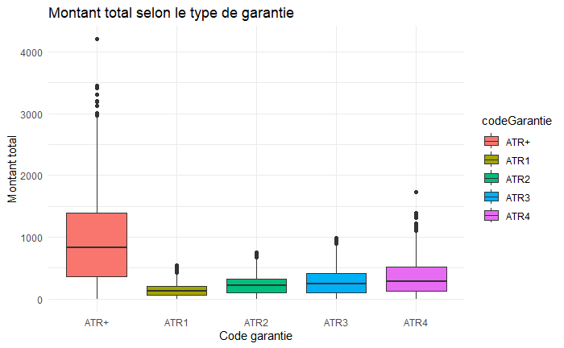

```r
# boxplot
ggplot(Base_sim, aes(x = codeGarantie, y = Mtt_total, fill = codeGarantie)) +
  geom_boxplot() +
  labs(title = "Montant total selon le type de garantie",
       x = "Code garantie",
       y = "Montant total") +
  theme_minimal()
```

> Montant total et qualite

```r
# Univarié
describe(Base_sim$qualite)
```

```
[33804 obs.]
nominal factor: "Adhérent" "Adhérent" "Adhérent" "Adhérent" "Adhérent" "Conjoint" "Adhérent" "Adhérent" "Adhérent" "Conjoint" ...
3 levels: Adhérent | Conjoint | Enfants
NAs: 0 (0%)

             n     %
Adhérent 25966  76.8
Conjoint  5744  17.0
Enfants   2094   6.2
Total    33804 100.0
```

```r
# test non parametrique de Kruskal-Wallis
kruskal.test(Mtt_total ~ qualite, data = Base_sim)
```

```
    Kruskal-Wallis rank sum test

data:  Mtt_total by qualite
Kruskal-Wallis chi-squared = 123.16, df = 2, p-value < 2.2e-16
```

```r
# Bivarié
print(aggregate(Mtt_total ~ qualite, data = Base_sim, FUN = mean))
```

```
   qualite Mtt_total
1 Adhérent  260.5685
2 Conjoint  292.4895
3  Enfants  254.2128
```

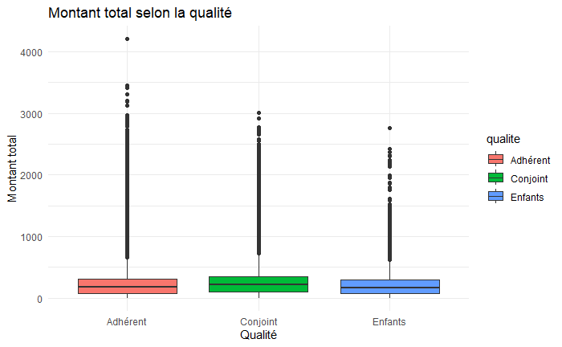

```r
# boxplot
ggplot(Base_sim, aes(x = qualite, y = Mtt_total, fill = qualite)) +
  geom_boxplot() +
  labs(title = "Montant total selon la qualité",
       x = "Qualité",
       y = "Montant total") +
  theme_minimal()
```

## 2 Préparation des données

```r
nomcol_y <- "Mtt_total"
modele <- Mtt_total ~ sexe + Age + qualite + codeGarantie + Exposition

data_mdl <- Base_sim
data_mdl$Mtt_total[data_mdl$Mtt_total <= 0] <- 1

set.seed(123)

index_train <- createDataPartition(data_mdl$Mtt_total, p = 0.75, list = FALSE)

train <- data_mdl[index_train, ]
test  <- data_mdl[-index_train, ]
```

> Definition de la validation croisee

```r
ctrl <- trainControl(
  method = "cv",
  number = 5,
  verboseIter = TRUE
)
```

### 2.1 Modélisation GLM

```r
glm_model <- train(
  modele,
  data = train,
  method = "glm",
  family = Gamma(link = "log"),
  trControl = ctrl
)
```

```r
# Prediction
pred_glm_test <- predict(glm_model, newdata = test)

RMSE(pred_glm_test, test$Mtt_total)
```

```
[1] 198.3447
```

### 2.2 Machine Learning

> Arbre de regression CART

```r
cart_model <- train(
  modele,
  data = train,
  method = "rpart",
  trControl = ctrl,
  tuneLength = 20
)
cart_model$bestTune
```

|  | cp |
| --- | --- |
| 4 | 0.001336537 |

> GBM

```r
grid_gbm <- expand.grid(
  interaction.depth = 1:6,
  n.trees = c(100,150,200),
  shrinkage = c(0.01,0.05,0.1),
  n.minobsinnode = 10
)

gbm_model <- train(
  modele,
  data = train,
  method = "gbm",
  trControl = ctrl,
  tuneGrid = grid_gbm,
  verbose = FALSE
)
gbm_model$bestTune
```

|  | n.trees | interaction.depth | shrinkage | n.minobsinnode |
| --- | --- | --- | --- | --- |
| 36 | 200 | 6 | 0.05 | 10 |

> Random forest

```r
grid_rf <- expand.grid(
  mtry = 1:5
)

rf_model <- train(
  modele,
  data = train,
  method = "rf",
  trControl = ctrl,
  tuneGrid = grid_rf,
  ntree = 200,
  importance = TRUE
)
rf_model$bestTune
```

|  | mtry |
| --- | --- |
| 4 | 4 |

### 2.3 Comparaison des modèles

> Interprétation de la figure

On compare les performances des modèles de régression : **CART**, **GLM**, **RF (Random Forest)** et **GBM (Gradient Boosting Machine)** selon trois métriques : **MAE**, **RMSE** et **R²**.

MAE (Mean Absolute Error)

- Le **MAE** mesure l’erreur moyenne absolue entre les prédictions et les valeurs réelles.
- **Plus le MAE est petit, meilleur est le modèle.**

RMSE (Root Mean Squared Error)

- Le **RMSE** mesure l’erreur quadratique moyenne, donc **pénalise davantage les grosses erreurs**.
- **Plus le RMSE est faible, meilleur est le modèle.**

R² (Coefficient de détermination)

- Le **R²** mesure la proportion de variance expliquée par le modèle.
- **Plus le R² est élevé (proche de 1), meilleur est le modèle.**

```r
results <- resamples(list(
  GLM = glm_model,
  CART = cart_model,
  GBM = gbm_model,
  RF = rf_model
))

summary(results)
```

```
Call:
summary.resamples(object = results)

Models: GLM, CART, GBM, RF
Number of resamples: 5

MAE
         Min.  1st Qu.   Median     Mean  3rd Qu.     Max. NA's
GLM  110.6395 111.8420 112.6902 112.8397 112.9474 116.0796    0
CART 114.7576 117.0843 118.4130 118.0245 119.1773 120.6902    0
GBM  106.2377 107.8973 108.2141 109.9141 113.1948 114.0266    0
RF   107.6172 108.8433 111.3675 111.0008 111.5241 115.6517    0

RMSE
         Min.  1st Qu.   Median     Mean  3rd Qu.     Max. NA's
GLM  193.8085 199.5134 199.7107 201.0642 203.3486 208.9398    0
CART 190.5966 192.1023 201.9484 199.7562 204.2860 209.8475    0
GBM  182.4879 188.9046 189.5467 194.9682 203.2606 210.6412    0
RF   189.9009 193.3986 194.5679 196.6162 195.7834 209.4305    0

Rsquared
          Min.   1st Qu.    Median      Mean   3rd Qu.      Max. NA's
GLM  0.5820605 0.6272004 0.6396130 0.6270509 0.6427368 0.6436437    0
CART 0.6098361 0.6273336 0.6313488 0.6276862 0.6341814 0.6357309    0
GBM  0.5951016 0.6331542 0.6493361 0.6457899 0.6632204 0.6881375    0
RF   0.6102778 0.6453368 0.6477156 0.6405977 0.6486205 0.6510379    0
```

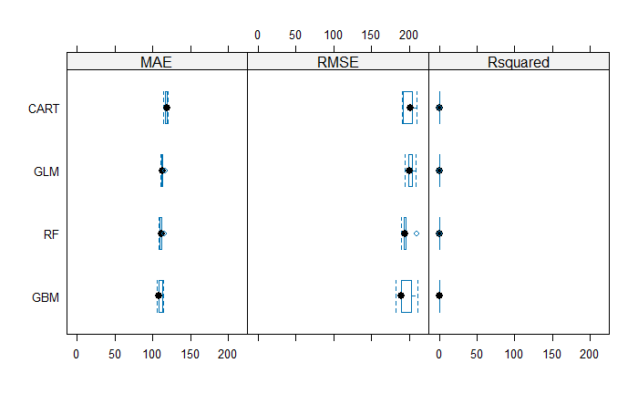

```r
bwplot(results)
```

> Predictions sur test

```r
pred_cart_test <- predict(cart_model, test)
pred_gbm_test  <- predict(gbm_model, test)
pred_rf_test   <- predict(rf_model, test)
```

> Erreurs

```r
RMSE(pred_cart_test, test$Mtt_total)
```

```
[1] 195.4114
```

```r
RMSE(pred_gbm_test, test$Mtt_total)
```

```
[1] 193.3335
```

```r
RMSE(pred_rf_test, test$Mtt_total)
```

```
[1] 193.7407
```

### 2.4 Prédictions sur la base totale

```r
models <- list(
  glm_Gamma  = glm_model,
  cart = cart_model,
  gbm  = gbm_model,
  rf   = rf_model
)

predictions <- lapply(models, predict, newdata = data_mdl)

error_frame <- data.frame(
  CodeINSEE = data_mdl$CodeINSEE,
  CodeBV    = data_mdl$CodeBV,
  sapply(predictions, function(p) data_mdl$Mtt_total - p)
)
```

> Verification de la performance globale

```r
RMSE(predict(glm_model,  newdata = data_mdl), data_mdl$Mtt_total)
```

```
[1] 200.3484
```

```r
RMSE(predict(cart_model, newdata = data_mdl), data_mdl$Mtt_total)
```

```
[1] 196.6857
```

```r
RMSE(predict(gbm_model,  newdata = data_mdl), data_mdl$Mtt_total)
```

```
[1] 192.8389
```

```r
RMSE(predict(rf_model,   newdata = data_mdl), data_mdl$Mtt_total)
```

```
[1] 185.1415
```

> Sauvegarde de la table pour la prochaine etape

```r
save(error_frame, file = "error_frame.RData")
```